# Part II - Summary of loan analysis findings

## by Bernard A. Buckman

## Investigation Overview

> This presentation presents some findings in our analysis of the prosper loan dataset. It will investigate the relation between loans taken (original loan amount), loan terms, borrower APR, borrower Rate, and Prosper Loan Ratings (Alpha) \ Key findings are:
> - The BorrowerAPR decrease with the increasing loan terms for people with HR through to C ratings. But this trend changes from prosperRating (Alpha) B through AA with longer loan terms (60 months) being higher.
> - Current loan status category is the highest loan status category in the dataset.
> - The BorrowerAPR decrease with the increasing loan terms for people with HR through to C ratings.

## Dataset Overview

> This data set contains prosper loan information for 113937 entries and 16 features.

```
(113937, 16)
```

## Visualization of BorrowerAPR and ProsperRating (Alpha)

> This shows that the BorrowerAPR and BorrowerRate decreases with increase ProsperRating (Alpha). That is, borrowers with improved ratings have the lowest APR. \ BorrowerAPR and BorrowerRate affects the Prosper Rating (Alpha)

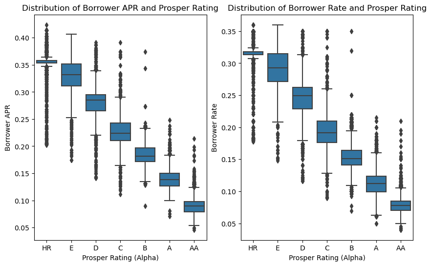

## Visualization of Loan Status Distribution

> This shows that Current is the highest loan status category in the dataset.

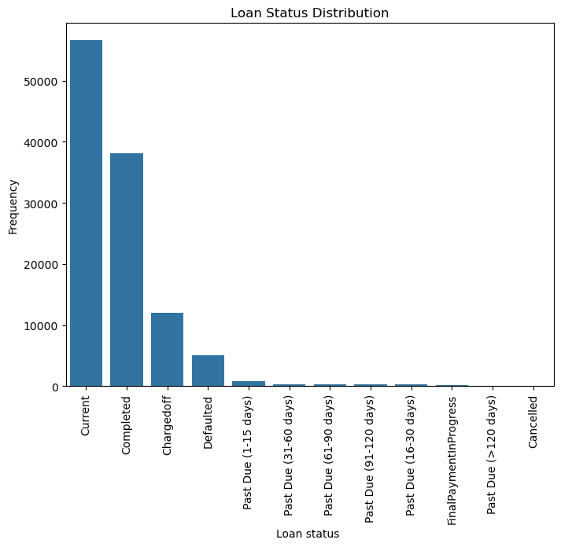

## Visualization of BorrowerAPR, ProsperRating (Alpha), Loan Terms

> This visualization shows the BorrowerAPR decrease with the increasing loan terms for people with HR through to C ratings. \ But this trend changes from prosperRating (Alpha) B through AA with longer loan terms (60 months) being higher.

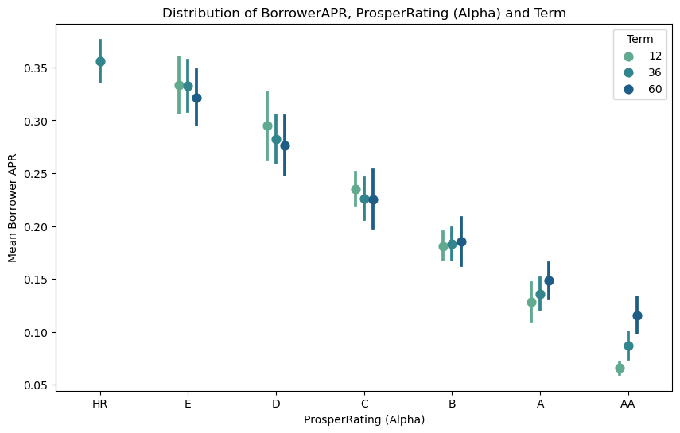